# Chapter 7: Recap

Guido Biele

27.04.2022

# Modeling interactions

We are going to use the Scarr-Rowe effect (or hypothesis) to look more closely on interaction effects. The Scarr-Rowe hypothesis states that the (genetic) **heritability of a trait depends on the environment**, such that the effects of genes are larger when environments are better. The underlying idea is that if everyone lives in a perfect environment, i.e. there is no variation in the relevant environment, then a trait will only depend on genes.

This interaction can be visualized as follows:

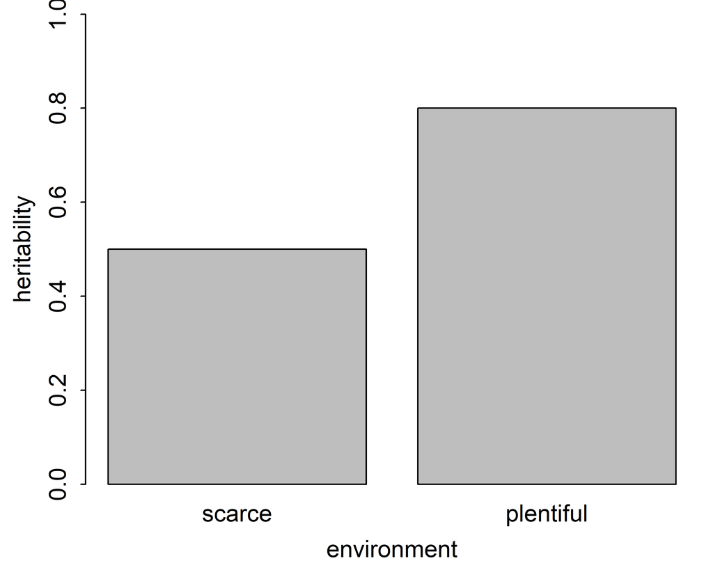

```r
par(mar=c(3,3,.5,.5), mgp=c(1.75,.5,0), tck=-.01)
heritability = c(scarce = 0.5, plentiful = 0.8)
barplot(heritability, ylab = "heritability", ylim = c(0,1), xlab = "environment")
```

Here is a DAG that describes such a model, where

- A = additive genetic effects
- C = common effects in a family
- E = idiosyncratic effects and measurement error

and the Scarr-Rowe effect means the the coefficient of the path $\small A \rightarrow IQ$ depends on $\small SES$.

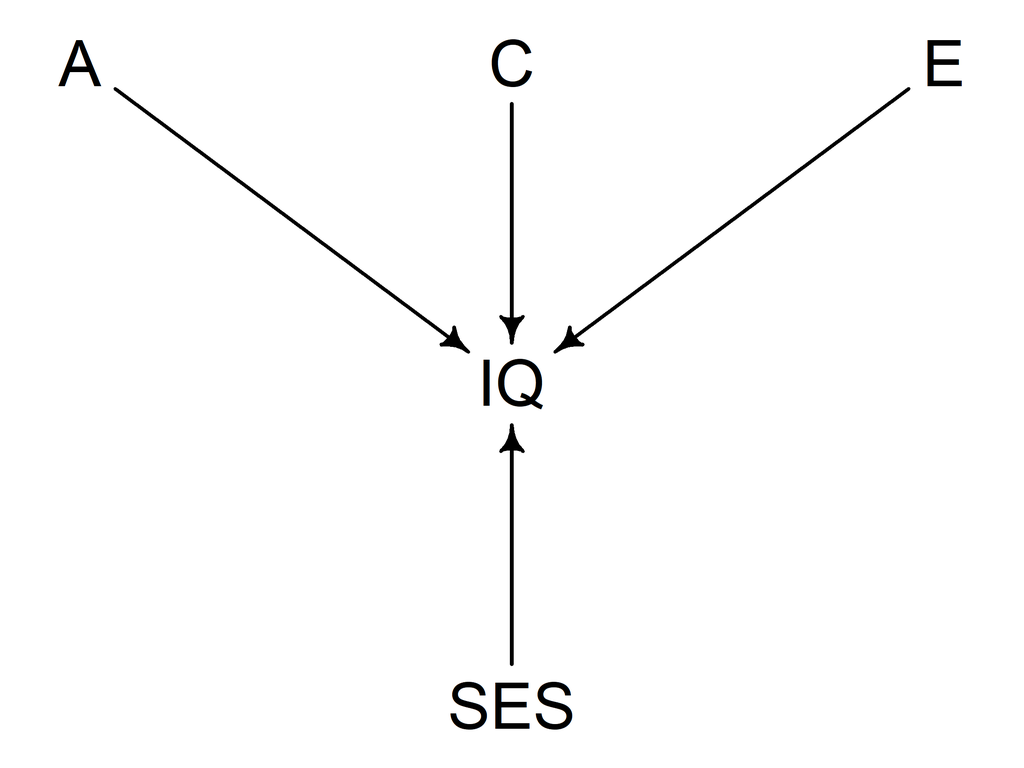

```r
library(dagitty)
dag = dagitty(
  "dag{
  IQ;
  A -> IQ;
  C -> IQ;
  E -> IQ;
  SES -> IQ;
  }")
coord.list =
  list(
    x=c(A=1,C=2,E=3,SES=2,IQ=2),
    y=c(A=-1,C=-1,E=-1,SES=1,IQ=0))
coordinates(dag) = coord.list
drawdag(dag, cex = 1.5)
```

Not that DAGs do not encode interaction effects by drawing an arrow from the moderator to the relevant path. Instead, there is a path from the moderator to the outcome variable. So the DAG only tells us that IQ is a function of four other variables $\small IQ = f(A,C,E,SES)$, but it does not tell us what the function $f()$ is. This could be $\small IQ = A + C + E + SES$, $\small IQ = A \cdot C \cdot E + SES$ or $\small IQ = A \cdot SES + C \cdot SES + E$, or $\small IQ = A \cdot SES + log(C) \cdot SES + E$ or any imaginable function that uses the variables.

Lets simulate data that show the the Scarr-Rowe effect, first our exogenous variables. To keep things simple, we assume that all variables are normally distributed:

```r
set.seed(12)
N = 1000
SES = rnorm(N,mean = 5,1)
A = rnorm(N,mean = 5,1)
C = rnorm(N,mean = 5,1)
E = rnorm(N, sd = 5)
```

Now comes the interesting part: Scarr-Rowe assumes that the effect or weight of genes depends on the SES. So we formulate the weight of genes as as a function of SES. For good measure, we also let the effect of the familial environment vary by SES.

```r
library(boot)
# we use inv.logit keep
# weights is a range 0-1
b_A = function(SES) 1 + inv.logit(SES-5)*3
b_C = function(SES) inv.logit(-SES+5)
```

We are literally defining the weight for A as a function of SES. This is one way to understand interactions. Here is a visualization of the weights:

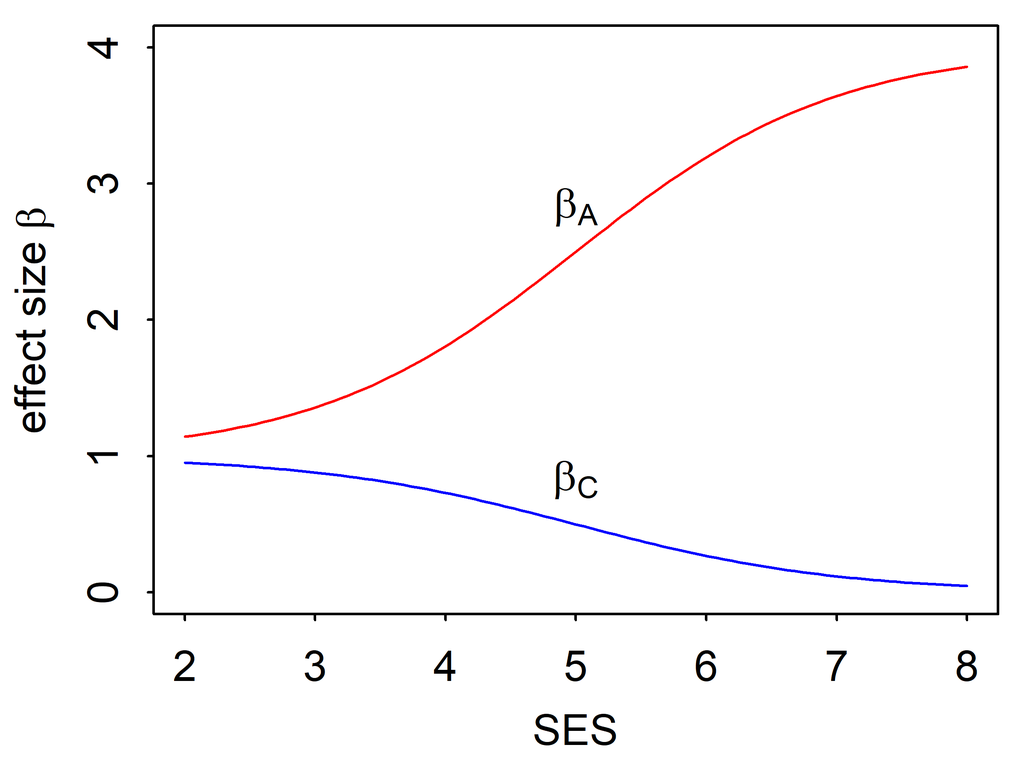

```r
par(mar=c(3,3,.5,.5), mgp=c(1.75,.5,0), tck=-.01)
curve(b_A(x),2,8, y = expression("effect size"~beta),
      xlab = "SES", ylim = c(0,4), col = "red")
curve(b_C(x),2,8, xlab = "SES", add = T, col = "blue")
text(c(5,5),
     c(b_A(5), b_C(5)),
     labels = c(expression(beta[A]),
                expression(beta[C])), pos = 3)
```

In this plot the interaction is not encoded by the fact that $\small \beta_A$ and $\small \beta_C$ have different slopes, but by the fact that both have a slope in the first place. The figure shows two interactions, because the effect size for $\small A$ and $small C$ changes with SES.

And now we can simulate IQ values from using exogenous variables and derived weights. We assume that IQ depends on familial factors $\small C$, additive genetic effects $\small A$ and $\small SES$:

```r
IQ = b_C(SES)*C + b_A(SES)*A + .5*SES
IQ = 65 + IQ*2 + E
```

If we just look at the bivariate associations between $\small A$ or $\small SES$ and $\small IQ$, we get the following plot:

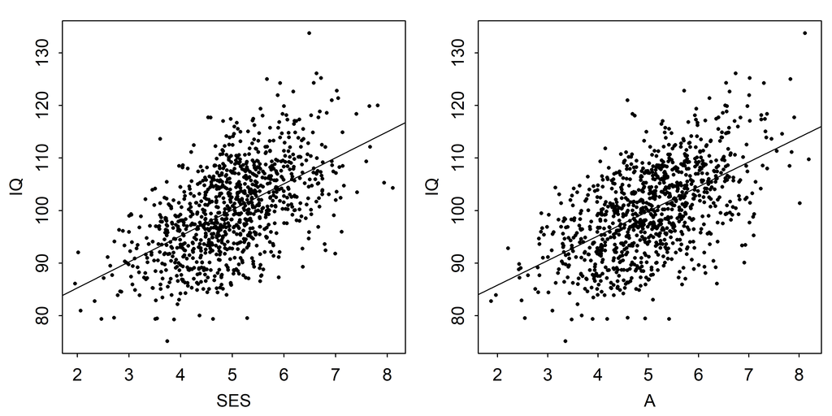

```r
par(mfrow = c(1,2),mar=c(3,3,1,.5), mgp=c(1.75,.5,0), tck=-.01)
plot(SES,IQ, pch = 16, cex = .5,)
abline(lm(IQ~SES))
plot(A,IQ, pch = 16, cex = .5,)
abline(lm(IQ~A))
```

```r
# plot(C,IQ)
# abline(lm(IQ~C))
```

```r
low.SES = which(SES < quantile(SES,.30))
high.SES = which(SES > quantile(SES,.70))
idx = c(low.SES,high.SES)
dt = data.frame(A = A[idx],
                C = C[idx],
                IQ = IQ[idx],
                SES = SES[idx],
                SES.c = c(rep(1,length(low.SES)),
                          rep(2,length(high.SES))))
```

Lets plot the association between $\small A$ and $\small IQ$ again, this time split by SES:

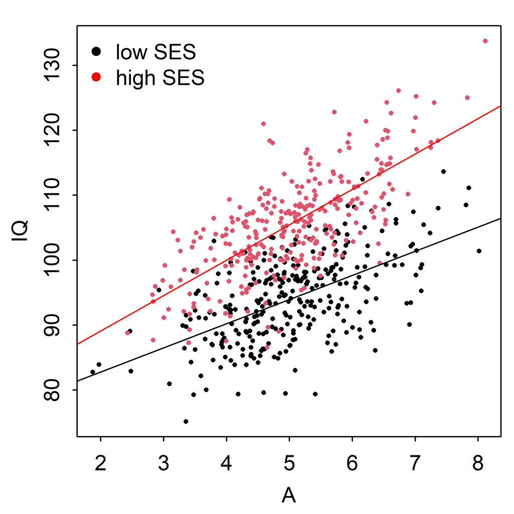

```r
low.SES = dt$SES.c == 1
high.SES = dt$SES.c == 2
par(mar=c(3,3,1,.5), mgp=c(1.75,.5,0), tck=-.01)
plot(IQ ~ A, data = dt, col = dt$SES.c, pch = 16, cex = .5,
     ylim = range(dt$IQ), ylab = "IQ", xlab = "A")
legend("topleft", pch = 16, col = c("black","red"),
       legend = c("low SES","high SES"), bty = "n")
abline(lm(IQ ~ A, data = dt[low.SES,]), col = "black")
abline(lm(IQ ~ A, data = dt[high.SES,]), col = "red")
```

We start with a simple linear regression and build successively more complex model. But first some intuitions on priors:

```r
IQ.A =
  quap(
    alist(
      IQ ~ dnorm(mu,sigma),
      mu <- a + b*(A - 5),
      a ~ dnorm(100,5),
      b ~ dnorm(0,8),
      sigma ~ dexp(.5)
    ),
    data=dt)
```

Lets quickly look at the pior predictions to make sure the piors are OK.

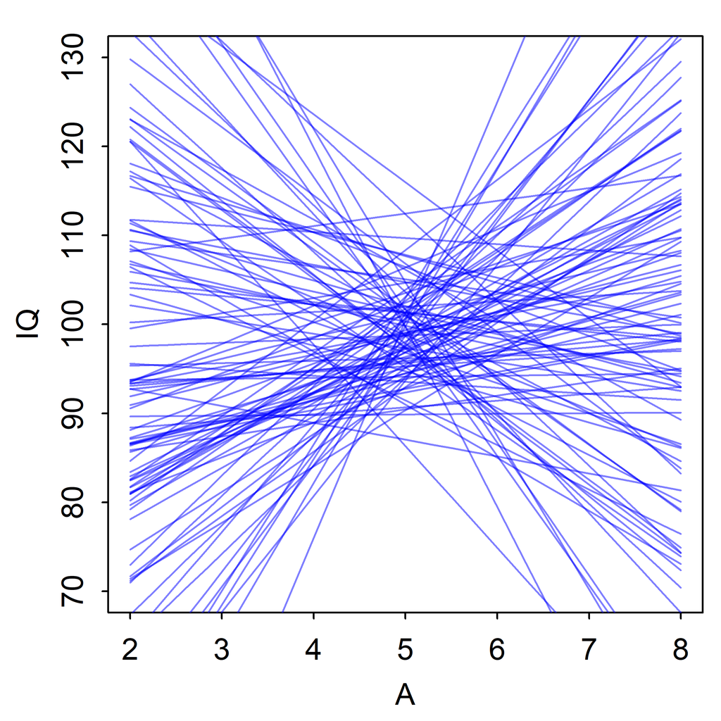

```r
prior <-extract.prior(IQ.A)
A <-seq(from=2,to=8,length.out=30)
mu <-link(IQ.A,post=prior,data=data.frame(A=A))
par(mar=c(3,3,1,.5), mgp=c(1.75,.5,0), tck=-.01)
plot(0,type = "n", xlim = c(2,8), ylim = c(70,130), ylab = "IQ", xlab = "A")
matlines(A,t(mu[1:100,]),type = "l", col = adjustcolor("blue", alpha = .5), lty = 1)
```

Yes, this looks good.